# Problem Statement for Baseball Player Clustering Project

### EDA and Data Cleaning

- Check for missing values
- Check distribution of data
- Check for correlation of data

```python
print(df.columns.tolist())
```

[output not shown]

```python
missing_values = df.isnull().sum()
print(missing_values[missing_values > 0])
```

```
n_bolts     388
hp_to_1b     38
dtype: int64
```

### Remove features bolts

Based on the above results, we can observe that the majority of players is missing the metrics n_bolts. This is an rare event where it counts the number of runs a player made over 30ft/s. It is not a direct measure of speed but a feature that marks players who have the capability of reaching exceptional speed. However, this does not infer average running speeds. Therefore, we will remove this feature from this analysis.

```python
hitting_metrics = ['hit', 'single', 'double', 'triple', 'home_run', 'strikeout', 'walk',
                   'k_percent', 'bb_percent']
df[hitting_metrics].describe()
```

|  | hit | single | double | triple | home_run | strikeout | walk | k_percent | bb_percent |
| --- | --- | --- | --- | --- | --- | --- | --- | --- | --- |
| count | 526.000000 | 526.000000 | 526.000000 | 526.000000 | 526.000000 | 526.000000 | 526.000000 | 526.000000 | 526.000000 |
| mean | 74.823194 | 48.623574 | 14.610266 | 1.307985 | 10.281369 | 76.737643 | 28.011407 | 23.755323 | 7.973194 |
| std | 48.174140 | 31.110845 | 10.107150 | 1.859906 | 9.350768 | 45.007551 | 20.680330 | 6.634447 | 2.975254 |
| min | 6.000000 | 2.000000 | 0.000000 | 0.000000 | 0.000000 | 8.000000 | 1.000000 | 4.300000 | 1.100000 |
| 25% | 32.000000 | 20.000000 | 6.000000 | 0.000000 | 3.000000 | 40.000000 | 12.000000 | 19.000000 | 5.900000 |
| 50% | 70.000000 | 47.000000 | 13.000000 | 1.000000 | 8.000000 | 69.000000 | 23.000000 | 23.800000 | 7.800000 |
| 75% | 109.750000 | 71.000000 | 22.000000 | 2.000000 | 15.000000 | 106.000000 | 41.000000 | 28.100000 | 9.975000 |
| max | 211.000000 | 161.000000 | 48.000000 | 14.000000 | 58.000000 | 218.000000 | 133.000000 | 46.200000 | 18.900000 |

```python
swing_metrics = ['avg_swing_speed', 'fast_swing_rate', 'blasts_contact', 'exit_velocity_avg',
                'launch_angle_avg', 'whiff_percent']

df[swing_metrics].describe()
```

|  | avg_swing_speed | fast_swing_rate | blasts_contact | exit_velocity_avg | launch_angle_avg | whiff_percent |
| --- | --- | --- | --- | --- | --- | --- |
| count | 526.000000 | 526.000000 | 526.000000 | 526.000000 | 526.000000 | 526.000000 |
| mean | 71.145817 | 20.186312 | 12.792205 | 88.427376 | 13.098099 | 25.868441 |
| std | 2.750870 | 18.018934 | 4.586925 | 2.427339 | 5.008556 | 6.559808 |
| min | 63.100000 | 0.000000 | 0.000000 | 79.700000 | -7.700000 | 6.900000 |
| 25% | 69.400000 | 5.900000 | 9.750000 | 86.900000 | 9.725000 | 21.500000 |
| 50% | 71.200000 | 14.900000 | 12.700000 | 88.400000 | 13.200000 | 25.650000 |
| 75% | 72.900000 | 30.000000 | 15.900000 | 89.900000 | 16.375000 | 30.100000 |
| max | 81.200000 | 98.600000 | 27.600000 | 96.200000 | 28.000000 | 45.200000 |

```python
speed_metrics = ['hp_to_1b', 'sprint_speed']

df[speed_metrics].describe()
```

|  | hp_to_1b | sprint_speed |
| --- | --- | --- |
| count | 488.000000 | 526.000000 |
| mean | 4.473402 | 27.296958 |
| std | 0.194188 | 1.369946 |
| min | 4.060000 | 22.800000 |
| 25% | 4.340000 | 26.425000 |
| 50% | 4.440000 | 27.400000 |
| 75% | 4.602500 | 28.300000 |
| max | 5.090000 | 30.500000 |

```python
features = [
    # Performance metrics
    'home_run', 'hit', 'pa', 'strikeout', 'walk', 'k_percent', 'bb_percent',
    # Batting characteristics
    'avg_swing_speed', 'exit_velocity_avg', 'launch_angle_avg',
    'whiff_percent', 'swing_percent',
    # Speed metrics
    'sprint_speed'
]
```

### Fill in the average for hp_to_1b

hp_to_1b is the metric of a player's average running time from homeplate to first base. This is measured when a player puts the ball in play and the batter runs to first base. In the above analysis, we observe that there are 38 missing values. This is interesting as it could signify one of the two possibilities:

1. Simply missing values
2. The batter has not put the ball in play; hence, has not had the opportunity to run to first base

Compared to the "bolts" feature, this feature is important as it measures your speed, therefore, instead of removing the feature, we will add the average speed into the hp_to_1b missing fields.

```python
### Filling in the average hp_to_1b
average_hp_to_1b = df['hp_to_1b'].mean()
df.loc[df['hp_to_1b'].isna(), 'hp_to_1b'] = average_hp_to_1b
```

```python
df[speed_metrics].describe()
```

|  | hp_to_1b | sprint_speed |
| --- | --- | --- |
| count | 526.000000 | 526.000000 |
| mean | 4.473402 | 27.296958 |
| std | 0.187029 | 1.369946 |
| min | 4.060000 | 22.800000 |
| 25% | 4.350000 | 26.425000 |
| 50% | 4.470000 | 27.400000 |
| 75% | 4.590000 | 28.300000 |
| max | 5.090000 | 30.500000 |

### EDA Visualizations

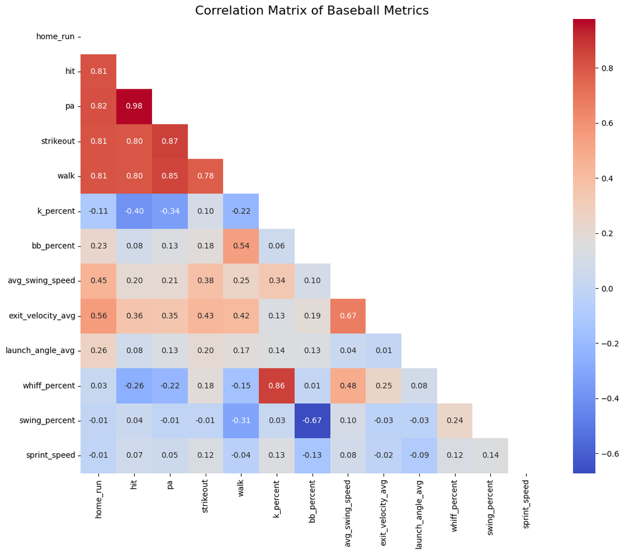

```python
plt.figure(figsize=(12, 10))
correlation = df[features].corr()
mask = np.triu(correlation)
sns.heatmap(correlation, annot=True, fmt=".2f", cmap='coolwarm', mask=mask)
plt.title('Correlation Matrix of Baseball Metrics', fontsize=16)
plt.tight_layout()
plt.show()
```

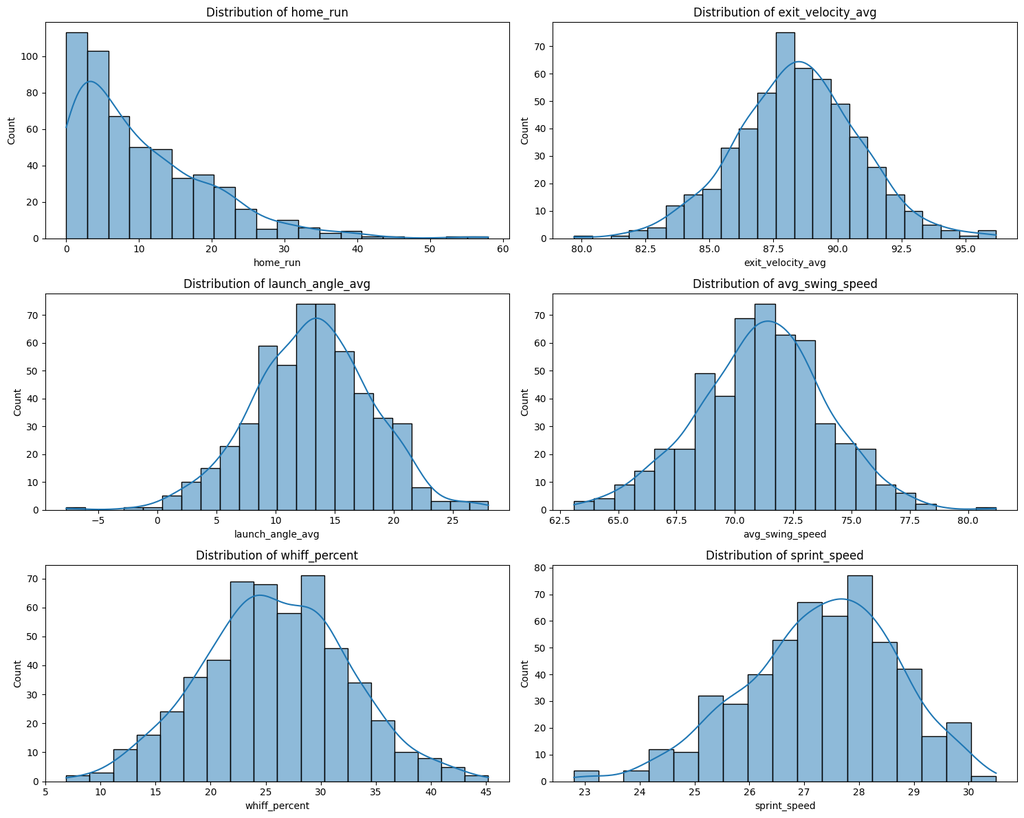

```python
fig, axes = plt.subplots(3, 2, figsize=(15, 12))
axes = axes.flatten()

key_features = ['home_run', 'exit_velocity_avg', 'launch_angle_avg',
               'avg_swing_speed', 'whiff_percent', 'sprint_speed']

for i, feature in enumerate(key_features):
    sns.histplot(df[feature].dropna(), kde=True, ax=axes[i])
    axes[i].set_title(f'Distribution of {feature}', fontsize=12)
    axes[i].set_xlabel(feature)
    axes[i].set_ylabel('Count')
plt.tight_layout()
plt.show()
```

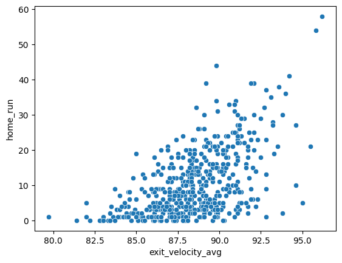

```python
sns.scatterplot(x='exit_velocity_avg', y='home_run', data=df)
plt.show()
```

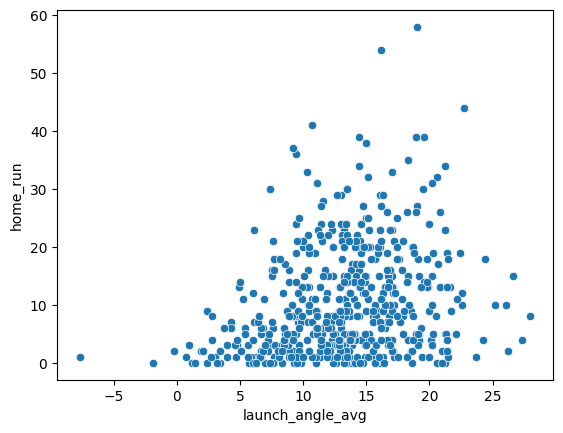

```python
sns.scatterplot(x='launch_angle_avg', y='home_run', data=df)
plt.show()
```

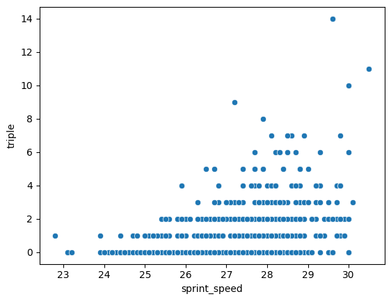

```python
sns.scatterplot(x='sprint_speed', y='triple', data=df)
plt.show()
```